# WGCNA Network Validation Against MaizeNetome

Fausto Rodriguez

2026-02-12

# Overview

**Purpose**: Validate WGCNA module networks against the MaizeNetome reference database and quantify network disruption caused by Inv4m introgression.

**Approach**: 1. Build binary correlation networks from CTRL and Inv4m expression data 2. Use same methodology as trans-network analysis (Pearson correlation, FDR < 0.05) 3. Compare edges to MaizeNetome reference 4. Quantify edge loss between CTRL and Inv4m conditions

**Key outputs**: - Edge counts: CTRL vs Inv4m - Reference vs Novel edge classification - Edge loss statistics (network disruption)

# Setup and Dependencies

```r
library(dplyr)
library(tidyr)
library(readr)
library(ggplot2)
library(patchwork)
library(eulerr)
```

# Load Data

## Expression Data

```r
# Load normalized expression data
voomR <- readRDS(
 file.path(paths$intermediate, "normalized_expression_voom_object_leaf_trt.rds")
)

# Load sample metadata from WGCNA pipeline
wgcna_run_dir <- here::here(
  "results", "inversion_paper", "field_perturbation",
  "run_20251231_201332"
)
sample_meta <- read_csv(
  file.path(wgcna_run_dir, "01_data_prep", "sample_metadata.csv"),
  show_col_types = FALSE
)

# Split samples by genotype
ctrl_samples <- sample_meta %>%
  filter(Genotype == "CTRL") %>%
  pull(sample_id)

inv4m_samples <- sample_meta %>%
  filter(Genotype == "Inv4m") %>%
  pull(sample_id)

cat("=== EXPRESSION DATA ===\n")
```

```
## === EXPRESSION DATA ===
```

```r
cat("Total genes:", nrow(voomR$E), "\n")
```

```
## Total genes: 24249
```

```r
cat("CTRL samples:", length(ctrl_samples), "\n")
```

```
## CTRL samples: 20
```

```r
cat("Inv4m samples:", length(inv4m_samples), "\n")
```

```
## Inv4m samples: 23
```

## WGCNA Module Genes

```r
# Load WGCNA module assignments (CTRL modules as reference)
ctrl_modules <- read_csv(
  file.path(wgcna_run_dir, "04_consensus_networks", "ctrl", "consensus_modules.csv"),
  show_col_types = FALSE
)

# Get genes assigned to modules (exclude grey/unassigned)
wgcna_genes <- ctrl_modules %>%
  filter(module != 0) %>%
  pull(gene)

# Filter to genes in expression matrix
wgcna_genes <- wgcna_genes[wgcna_genes %in% rownames(voomR$E)]

cat("\n=== WGCNA GENES ===\n")
```

```
##
## === WGCNA GENES ===
```

```r
cat("Genes in modules:", length(wgcna_genes), "\n")
```

```
## Genes in modules: 405
```

```r
cat("Genes in expression matrix:", sum(wgcna_genes %in% rownames(voomR$E)), "\n")
```

```
## Genes in expression matrix: 405
```

## MaizeNetome Reference

```r
# Load MaizeNetome coexpression edges (same as trans-network analysis)
left_flanking_maizenetome <- read.csv(
  file.path(paths$data, "left_MaizeNetome_coexpression_edges.csv")
)
Inv4m_maizenetome <- read.csv(
  file.path(paths$data, "inv4m_MaizeNetome_coexpression_edges.csv")
)
right_flanking_maizenetome <- read.csv(
  file.path(paths$data, "right_MaizeNetome_coexpression_edges.csv")
)

MaizeNetome <- rbind(
  left_flanking_maizenetome %>%
    separate_longer_delim(cols = Direct.Connetation.Node, delim = "\n") %>%
    mutate(network = "coexpression"),
  Inv4m_maizenetome %>%
    separate_longer_delim(cols = Direct.Connetation.Node, delim = "\n") %>%
    mutate(network = "coexpression"),
  right_flanking_maizenetome %>%
    separate_longer_delim(cols = Direct.Connetation.Node, delim = "\n") %>%
    mutate(network = "coexpression")
) %>%
  dplyr::rename(Direct.Connection = Direct.Connetation.Node)

cat("\n=== MAIZENETOME ===\n")
```

```
##
## === MAIZENETOME ===
```

```r
cat("Total edges (v4 IDs):", nrow(MaizeNetome), "\n")
```

```
## Total edges (v4 IDs): 640599
```

```r
# Convert v4 to v5 gene IDs
v4_v5 <- read.table(
  file = file.path(paths$data, "B73v4_to_B73v5.tsv"),
  sep = "\t",
  header = FALSE
) %>%
  dplyr::rename(v4 = V1, v5 = V2) %>%
  separate_longer_delim(cols = v5, delim = ",")

MaizeNetome_v5 <- MaizeNetome %>%
  left_join(v4_v5, by = c("Element.ID" = "v4")) %>%
  dplyr::rename(Element.ID.v5 = v5) %>%
  filter(!is.na(Element.ID.v5)) %>%
  left_join(v4_v5, by = c("Direct.Connection" = "v4")) %>%
  dplyr::rename(Direct.Connection.v5 = v5) %>%
  filter(!is.na(Direct.Connection.v5))

# Create edge set for fast lookup (undirected - sort gene pairs)
maizenetome_edges <- MaizeNetome_v5 %>%
  rowwise() %>%
  mutate(
    gene1 = min(Element.ID.v5, Direct.Connection.v5),
    gene2 = max(Element.ID.v5, Direct.Connection.v5),
    edge_id = paste(gene1, gene2, sep = "_")
  ) %>%
  ungroup() %>%
  distinct(edge_id, .keep_all = TRUE)

cat("Edges after v4->v5 conversion:", nrow(MaizeNetome_v5), "\n
")
```

```
## Edges after v4->v5 conversion: 767533
```

```r
cat("Unique undirected edges:", nrow(maizenetome_edges), "\n")
```

```
## Unique undirected edges: 704921
```

# Build Correlation Networks

## Helper Functions

```r
#' Build binary edge list from expression matrix
#'
#' @param expr Expression matrix (genes x samples)
#' @param genes Genes to include
#' @param fdr_threshold FDR threshold for significance
#'
#' @return Data frame with significant edges
build_correlation_network <- function(expr, genes, fdr_threshold = 0.05) {

  # Filter to genes in expression matrix
  genes <- genes[genes %in% rownames(expr)]
  expr_subset <- expr[genes, ]

  n_genes <- length(genes)
  n_samples <- ncol(expr_subset)

  cat("Building network for", n_genes, "genes x", n_samples, "samples\n")
  cat("Total possible edges:", n_genes * (n_genes - 1) / 2, "\n")

 # Compute correlation matrix
  cor_matrix <- cor(t(expr_subset), use = "pairwise.complete.obs")

  # Compute p-values for correlations
  # t-statistic: t = r * sqrt((n-2)/(1-r^2))
  t_matrix <- cor_matrix * sqrt((n_samples - 2) / (1 - cor_matrix^2))
  p_matrix <- 2 * pt(-abs(t_matrix), df = n_samples - 2)

  # Extract lower triangle (undirected network)
  lower_idx <- which(lower.tri(cor_matrix), arr.ind = TRUE)

  edges_df <- data.frame(
    gene1 = genes[lower_idx[, 1]],
    gene2 = genes[lower_idx[, 2]],
    r = cor_matrix[lower_idx],
    p_value = p_matrix[lower_idx]
  )

  # FDR correction
  edges_df$p_adj <- p.adjust(edges_df$p_value, method = "fdr")

  # Filter significant edges
  sig_edges <- edges_df %>%
    filter(p_adj < fdr_threshold) %>%
    rowwise() %>%
    mutate(
      # Ensure consistent ordering for comparison
      g1 = min(gene1, gene2),
      g2 = max(gene1, gene2),
      edge_id = paste(g1, g2, sep = "_")
    ) %>%
    ungroup() %>%
    dplyr::select(gene1 = g1, gene2 = g2, edge_id, r, p_value, p_adj)

  cat("Significant edges (FDR <", fdr_threshold, "):", nrow(sig_edges), "\n")

  return(sig_edges)
}

#' Check edges against MaizeNetome
#'
#' @param edges Edge data frame with edge_id column
#' @param maizenetome_edge_ids Vector of MaizeNetome edge IDs
#'
#' @return Edge data frame with in_maizenetome column
check_maizenetome <- function(edges, maizenetome_edge_ids) {
  edges %>%
    mutate(in_maizenetome = edge_id %in% maizenetome_edge_ids)
}
```

## CTRL Network

```r
cat("=== BUILDING CTRL NETWORK ===\n\n")
```

```
## === BUILDING CTRL NETWORK ===
```

```r
# Extract CTRL expression
expr_ctrl <- voomR$E[, ctrl_samples]

# Build network
ctrl_edges <- build_correlation_network(
  expr = expr_ctrl,
  genes = wgcna_genes,
  fdr_threshold = 0.05
)
```

```
## Building network for 405 genes x 20 samples
## Total possible edges: 81810
## Significant edges (FDR < 0.05 ): 12593
```

```r
# Check against MaizeNetome
ctrl_edges <- check_maizenetome(ctrl_edges, maizenetome_edges$edge_id)

cat("\n=== CTRL NETWORK SUMMARY ===\n")
```

```
##
## === CTRL NETWORK SUMMARY ===
```

```r
cat("Total edges:", nrow(ctrl_edges), "\n")
```

```
## Total edges: 12593
```

```r
cat("Reference (in MaizeNetome):", sum(ctrl_edges$in_maizenetome), "\n")
```

```
## Reference (in MaizeNetome): 337
```

```r
cat("Novel (not in MaizeNetome):", sum(!ctrl_edges$in_maizenetome), "\n")
```

```
## Novel (not in MaizeNetome): 12256
```

```r
cat("% in MaizeNetome:", round(100 * mean(ctrl_edges$in_maizenetome), 2), "%\n")
```

```
## % in MaizeNetome: 2.68 %
```

## Inv4m Network

```r
cat("=== BUILDING INV4M NETWORK ===\n\n")
```

```
## === BUILDING INV4M NETWORK ===
```

```r
# Extract Inv4m expression
expr_inv4m <- voomR$E[, inv4m_samples]

# Build network
inv4m_edges <- build_correlation_network(
  expr = expr_inv4m,
  genes = wgcna_genes,
  fdr_threshold = 0.05
)
```

```
## Building network for 405 genes x 23 samples
## Total possible edges: 81810
## Significant edges (FDR < 0.05 ): 9460
```

```r
# Check against MaizeNetome
inv4m_edges <- check_maizenetome(inv4m_edges, maizenetome_edges$edge_id)

cat("\n=== INV4M NETWORK SUMMARY ===\n")
```

```
##
## === INV4M NETWORK SUMMARY ===
```

```r
cat("Total edges:", nrow(inv4m_edges), "\n")
```

```
## Total edges: 9460
```

```r
cat("Reference (in MaizeNetome):", sum(inv4m_edges$in_maizenetome), "\n")
```

```
## Reference (in MaizeNetome): 280
```

```r
cat("Novel (not in MaizeNetome):", sum(!inv4m_edges$in_maizenetome), "\n")
```

```
## Novel (not in MaizeNetome): 9180
```

```r
cat("% in MaizeNetome:", round(100 * mean(inv4m_edges$in_maizenetome), 2), "%\n")
```

```
## % in MaizeNetome: 2.96 %
```

# Compare CTRL vs Inv4m Networks

## Edge Overlap Analysis

```r
# Create edge sets
ctrl_edge_set <- ctrl_edges$edge_id
inv4m_edge_set <- inv4m_edges$edge_id

# Calculate overlaps
shared_edges <- intersect(ctrl_edge_set, inv4m_edge_set)
ctrl_only_edges <- setdiff(ctrl_edge_set, inv4m_edge_set)
inv4m_only_edges <- setdiff(inv4m_edge_set, ctrl_edge_set)

cat("=== EDGE COMPARISON ===\n")
```

```
## === EDGE COMPARISON ===
```

```r
cat("Shared edges (in both):", length(shared_edges), "\n")
```

```
## Shared edges (in both): 3230
```

```r
cat("CTRL-only edges (lost in Inv4m):", length(ctrl_only_edges), "\n")
```

```
## CTRL-only edges (lost in Inv4m): 9363
```

```r
cat("Inv4m-only edges (gained):", length(inv4m_only_edges), "\n")
```

```
## Inv4m-only edges (gained): 6230
```

```r
cat("\nEdge loss rate:", round(100 * length(ctrl_only_edges) / length(ctrl_edge_set), 2), "%\n")
```

```
##
## Edge loss rate: 74.35 %
```

```r
cat("Edge gain rate:", round(100 * length(inv4m_only_edges) / length(inv4m_edge_set), 2), "%\n")
```

```
## Edge gain rate: 65.86 %
```

```r
# Categorize all edges
all_edges <- unique(c(ctrl_edge_set, inv4m_edge_set))

edge_summary <- data.frame(edge_id = all_edges) %>%
  mutate(
    in_ctrl = edge_id %in% ctrl_edge_set,
    in_inv4m = edge_id %in% inv4m_edge_set,
    in_maizenetome = edge_id %in% maizenetome_edges$edge_id,
    category = case_when(
      in_ctrl & in_inv4m ~ "Shared",
      in_ctrl & !in_inv4m ~ "Lost",
      !in_ctrl & in_inv4m ~ "Gained"
    )
  )

cat("\n=== EDGE CATEGORIES BY MAIZENETOME STATUS ===\n")
```

```
##
## === EDGE CATEGORIES BY MAIZENETOME STATUS ===
```

```r
edge_summary %>%
  group_by(category, in_maizenetome) %>%
  summarise(n = n(), .groups = "drop") %>%
  pivot_wider(names_from = in_maizenetome, values_from = n, names_prefix = "MaizeNetome_") %>%
  print()
```

```
## # A tibble: 3 × 3
##   category MaizeNetome_FALSE MaizeNetome_TRUE
##   <chr>                <int>            <int>
## 1 Gained                6069              161
## 2 Lost                  9145              218
## 3 Shared                3111              119
```

## Sign Concordance Analysis

Since WGCNA uses signed networks, we verify that “shared” edges have concordant correlation signs between CTRL and Inv4m. An edge with r = +0.8 in CTRL and r = -0.7 in Inv4m would be significant in both but represents a biological reversal, not preservation.

```r
# Join CTRL and Inv4m edges to compare correlation signs
shared_edge_correlations <- inner_join(
 ctrl_edges %>% dplyr::select(edge_id, r_ctrl = r),
  inv4m_edges %>% dplyr::select(edge_id, r_inv4m = r),
  by = "edge_id"
) %>%
  mutate(
    sign_ctrl = sign(r_ctrl),
    sign_inv4m = sign(r_inv4m),
    same_sign = sign_ctrl == sign_inv4m,
    sign_pattern = case_when(
      r_ctrl > 0 & r_inv4m > 0 ~ "pos → pos",
      r_ctrl > 0 & r_inv4m < 0 ~ "pos → neg (FLIP)",
      r_ctrl < 0 & r_inv4m > 0 ~ "neg → pos (FLIP)",
      r_ctrl < 0 & r_inv4m < 0 ~ "neg → neg"
    )
  )

cat("=== SIGN CONCORDANCE IN SHARED EDGES ===\n")
```

```
## === SIGN CONCORDANCE IN SHARED EDGES ===
```

```r
cat("Total shared edges:", nrow(shared_edge_correlations), "\n\n")
```

```
## Total shared edges: 3230
```

```r
cat("Same sign (truly preserved):", sum(shared_edge_correlations$same_sign),
    "(", round(100 * mean(shared_edge_correlations$same_sign), 1), "%)\n")
```

```
## Same sign (truly preserved): 3134 ( 97 %)
```

```r
cat("Opposite sign (sign flip):", sum(!shared_edge_correlations$same_sign),
    "(", round(100 * mean(!shared_edge_correlations$same_sign), 1), "%)\n\n")
```

```
## Opposite sign (sign flip): 96 ( 3 %)
```

```r
cat("=== SIGN PATTERN BREAKDOWN ===\n")
```

```
## === SIGN PATTERN BREAKDOWN ===
```

```r
shared_edge_correlations %>%
  count(sign_pattern) %>%
  mutate(pct = round(100 * n / sum(n), 1)) %>%
  arrange(desc(n)) %>%
  print()
```

```
## # A tibble: 4 × 3
##   sign_pattern         n   pct
##   <chr>            <int> <dbl>
## 1 pos → pos         2202  68.2
## 2 neg → neg          932  28.9
## 3 neg → pos (FLIP)    57   1.8
## 4 pos → neg (FLIP)    39   1.2
```

```r
# Store for later use
n_truly_preserved <- sum(shared_edge_correlations$same_sign)
n_sign_flips <- sum(!shared_edge_correlations$same_sign)
```

```r
# Check sign concordance specifically for MaizeNetome edges
shared_mn_correlations <- shared_edge_correlations %>%
  filter(edge_id %in% maizenetome_edges$edge_id)

cat("\n=== SIGN CONCORDANCE IN MAIZENETOME EDGES ===\n")
```

```
##
## === SIGN CONCORDANCE IN MAIZENETOME EDGES ===
```

```r
cat("MaizeNetome edges in both networks:", nrow(shared_mn_correlations), "\n")
```

```
## MaizeNetome edges in both networks: 119
```

```r
cat("Same sign:", sum(shared_mn_correlations$same_sign),
    "(", round(100 * mean(shared_mn_correlations$same_sign), 1), "%)\n")
```

```
## Same sign: 118 ( 99.2 %)
```

```r
cat("Sign flip:", sum(!shared_mn_correlations$same_sign),
    "(", round(100 * mean(!shared_mn_correlations$same_sign), 1), "%)\n")
```

```
## Sign flip: 1 ( 0.8 %)
```

```r
# Store for summary
n_mn_truly_preserved <- sum(shared_mn_correlations$same_sign)
n_mn_sign_flips <- sum(!shared_mn_correlations$same_sign)
```

# Network Statistics Summary

```r
# Compile network statistics
network_stats <- tibble(
  Metric = c(
    "WGCNA genes analyzed",
    "Possible edges",
    "--- CTRL Network ---",
    "CTRL total edges",
    "CTRL Reference edges (in MaizeNetome)",
    "CTRL Novel edges (not in MaizeNetome)",
    "CTRL % in MaizeNetome",
    "--- Inv4m Network ---",
    "Inv4m total edges",
    "Inv4m Reference edges (in MaizeNetome)",
    "Inv4m Novel edges (not in MaizeNetome)",
    "Inv4m % in MaizeNetome",
    "--- Network Disruption ---",
    "Shared edges (significant in both)",
    "Lost edges (CTRL only)",
    "Gained edges (Inv4m only)",
    "Edge loss rate (%)",
    "Edge gain rate (%)",
    "Net edge change",
    "--- Sign Concordance ---",
    "Shared edges with same sign",
    "Shared edges with sign flip",
    "% same sign",
    "MaizeNetome edges same sign",
    "MaizeNetome edges sign flip"
  ),
  Value = c(
    length(wgcna_genes),
    length(wgcna_genes) * (length(wgcna_genes) - 1) / 2,
    "",
    nrow(ctrl_edges),
    sum(ctrl_edges$in_maizenetome),
    sum(!ctrl_edges$in_maizenetome),
    round(100 * mean(ctrl_edges$in_maizenetome), 2),
    "",
    nrow(inv4m_edges),
    sum(inv4m_edges$in_maizenetome),
    sum(!inv4m_edges$in_maizenetome),
    round(100 * mean(inv4m_edges$in_maizenetome), 2),
    "",
    length(shared_edges),
    length(ctrl_only_edges),
    length(inv4m_only_edges),
    round(100 * length(ctrl_only_edges) / length(ctrl_edge_set), 2),
    round(100 * length(inv4m_only_edges) / length(inv4m_edge_set), 2),
    nrow(inv4m_edges) - nrow(ctrl_edges),
    "",
    n_truly_preserved,
    n_sign_flips,
    round(100 * n_truly_preserved / length(shared_edges), 2),
    n_mn_truly_preserved,
    n_mn_sign_flips
  )
)

print(network_stats)
```

```
## # A tibble: 25 × 2
##    Metric                                 Value
##    <chr>                                  <chr>
##  1 WGCNA genes analyzed                   "405"
##  2 Possible edges                         "81810"
##  3 --- CTRL Network ---                   ""
##  4 CTRL total edges                       "12593"
##  5 CTRL Reference edges (in MaizeNetome)  "337"
##  6 CTRL Novel edges (not in MaizeNetome)  "12256"
##  7 CTRL % in MaizeNetome                  "2.68"
##  8 --- Inv4m Network ---                  ""
##  9 Inv4m total edges                      "9460"
## 10 Inv4m Reference edges (in MaizeNetome) "280"
## # ℹ 15 more rows
```

```r
write_csv(network_stats, file.path(paths$intermediate, "wgcna_maizenetome_validation_stats.csv"))
```

# Visualization

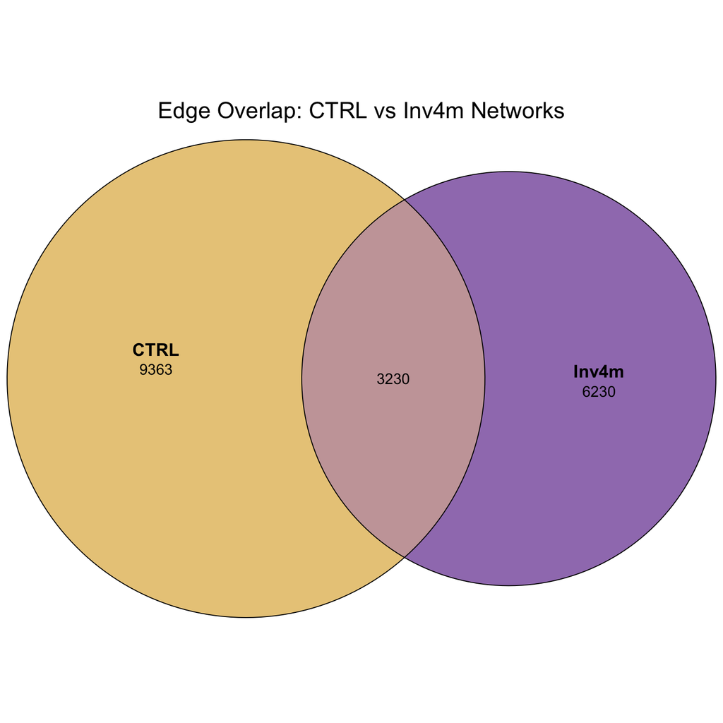

```r
# Create sets for Euler diagram
# Note: MaizeNetome is much larger, so we focus on overlap with our edges
our_edges <- unique(c(ctrl_edge_set, inv4m_edge_set))
maizenetome_relevant <- maizenetome_edges$edge_id[maizenetome_edges$edge_id %in% our_edges]

euler_data <- list(
  CTRL = ctrl_edge_set,
  Inv4m = inv4m_edge_set
)

p_euler <- plot(
  euler(euler_data),
  quantities = TRUE,
  fills = list(fill = c("#DAA520", "#551A8B"), alpha = 0.6),
  labels = list(fontsize = 14),
  main = "Edge Overlap: CTRL vs Inv4m Networks"
)

print(p_euler)
```

```r
# Save
pdf(file.path(paths$figures, "wgcna_edge_euler.pdf"), width = 8, height = 8)
print(p_euler)
dev.off()
```

## Bar Plot: Edge Counts by Category

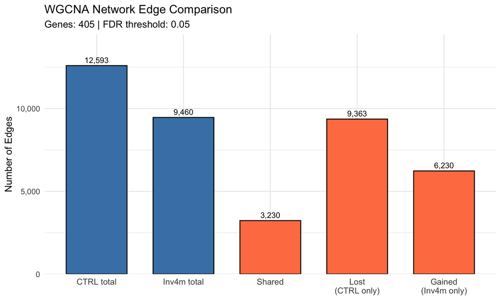

```r
edge_counts <- data.frame(
  Category = c("CTRL total", "Inv4m total", "Shared", "Lost\n(CTRL only)", "Gained\n(Inv4m only)"),
  Count = c(
    nrow(ctrl_edges),
    nrow(inv4m_edges),
    length(shared_edges),
    length(ctrl_only_edges),
    length(inv4m_only_edges)
  ),
  Type = c("Network", "Network", "Comparison", "Comparison", "Comparison")
)

edge_counts$Category <- factor(edge_counts$Category, levels = edge_counts$Category)

p_bar <- ggplot(edge_counts, aes(x = Category, y = Count, fill = Type)) +
  geom_col(color = "black", width = 0.7) +
  geom_text(aes(label = scales::comma(Count)), vjust = -0.5, size = 4) +
  scale_fill_manual(values = c("Network" = "steelblue", "Comparison" = "coral")) +
  scale_y_continuous(labels = scales::comma, expand = expansion(mult = c(0, 0.15))) +
  theme_minimal(base_size = 14) +
  theme(
    legend.position = "none",
    axis.text.x = element_text(size = 12)
  ) +
  labs(
    title = "WGCNA Network Edge Comparison",
    subtitle = paste0("Genes: ", length(wgcna_genes), " | FDR threshold: 0.05"),
    x = NULL,
    y = "Number of Edges"
  )

print(p_bar)
```

```r
ggsave(
  file.path(paths$figures, "wgcna_edge_comparison_barplot.pdf"),
  p_bar, width = 10, height = 6
)
ggsave(
  file.path(paths$figures, "wgcna_edge_comparison_barplot.png"),
  p_bar, width = 10, height = 6, dpi = 300
)
```

## MaizeNetome Validation: Reference vs Novel

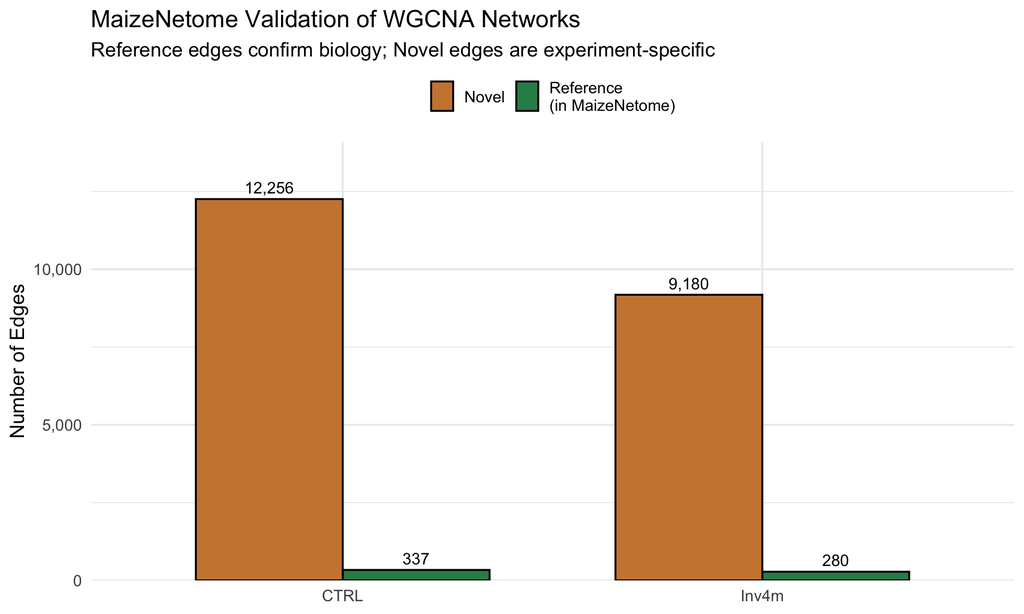

```r
validation_data <- data.frame(
  Network = rep(c("CTRL", "Inv4m"), each = 2),
  EdgeType = rep(c("Reference\n(in MaizeNetome)", "Novel"), 2),
  Count = c(
    sum(ctrl_edges$in_maizenetome),
    sum(!ctrl_edges$in_maizenetome),
    sum(inv4m_edges$in_maizenetome),
    sum(!inv4m_edges$in_maizenetome)
  )
)

p_validation <- ggplot(validation_data, aes(x = Network, y = Count, fill = EdgeType)) +
  geom_col(position = "dodge", color = "black", width = 0.7) +
  geom_text(
    aes(label = scales::comma(Count)),
    position = position_dodge(width = 0.7),
    vjust = -0.5, size = 4
  ) +
  scale_fill_manual(values = c("Reference\n(in MaizeNetome)" = "#2E8B57", "Novel" = "#CD853F")) +
  scale_y_continuous(labels = scales::comma, expand = expansion(mult = c(0, 0.15))) +
  theme_minimal(base_size = 14) +
  theme(legend.position = "top") +
  labs(
    title = "MaizeNetome Validation of WGCNA Networks",
    subtitle = "Reference edges confirm biology; Novel edges are experiment-specific",
    x = NULL,
    y = "Number of Edges",
    fill = NULL
  )

print(p_validation)
```

```r
ggsave(
  file.path(paths$figures, "wgcna_maizenetome_validation.pdf"),
  p_validation, width = 10, height = 6
)
ggsave(
  file.path(paths$figures, "wgcna_maizenetome_validation.png"),
  p_validation, width = 10, height = 6, dpi = 300
)
```

## Edge Loss by MaizeNetome Status

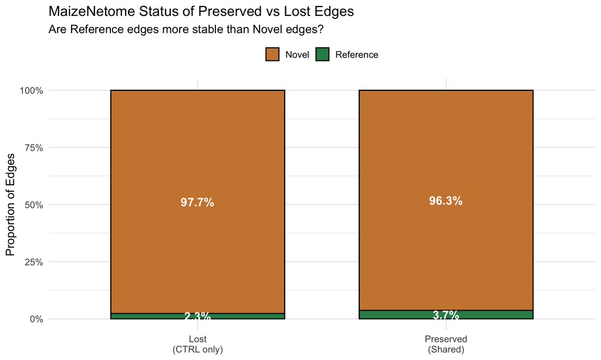

```r
# Are lost edges more likely to be Reference or Novel?
lost_edge_df <- ctrl_edges %>%
  filter(edge_id %in% ctrl_only_edges)

shared_edge_df <- ctrl_edges %>%
  filter(edge_id %in% shared_edges)

loss_by_type <- data.frame(
  Category = c("Preserved\n(Shared)", "Preserved\n(Shared)", "Lost\n(CTRL only)", "Lost\n(CTRL only)"),
  MaizeNetome = c("Reference", "Novel", "Reference", "Novel"),
  Count = c(
    sum(shared_edge_df$in_maizenetome),
    sum(!shared_edge_df$in_maizenetome),
    sum(lost_edge_df$in_maizenetome),
    sum(!lost_edge_df$in_maizenetome)
  )
)

# Add percentages within category
loss_by_type <- loss_by_type %>%
  group_by(Category) %>%
  mutate(
    Total = sum(Count),
    Pct = round(100 * Count / Total, 1)
  ) %>%
  ungroup()

p_loss <- ggplot(loss_by_type, aes(x = Category, y = Count, fill = MaizeNetome)) +
  geom_col(position = "fill", color = "black", width = 0.7) +
  geom_text(
    aes(label = paste0(Pct, "%")),
    position = position_fill(vjust = 0.5),
    size = 5, color = "white", fontface = "bold"
  ) +
  scale_fill_manual(values = c("Reference" = "#2E8B57", "Novel" = "#CD853F")) +
  scale_y_continuous(labels = scales::percent) +
  theme_minimal(base_size = 14) +
  theme(legend.position = "top") +
  labs(
    title = "MaizeNetome Status of Preserved vs Lost Edges",
    subtitle = "Are Reference edges more stable than Novel edges?",
    x = NULL,
    y = "Proportion of Edges",
    fill = NULL
  )

print(p_loss)
```

```r
ggsave(
  file.path(paths$figures, "wgcna_edge_loss_by_maizenetome.pdf"),
  p_loss, width = 8, height = 6
)
```

```r
# Fisher's exact test: Are Reference edges more likely to be preserved?
fisher_table <- matrix(
  c(
    sum(shared_edge_df$in_maizenetome),    # Preserved & Reference
    sum(!shared_edge_df$in_maizenetome),   # Preserved & Novel
    sum(lost_edge_df$in_maizenetome),      # Lost & Reference
    sum(!lost_edge_df$in_maizenetome)      # Lost & Novel
  ),
  nrow = 2,
  dimnames = list(
    c("Reference", "Novel"),
    c("Preserved", "Lost")
  )
)

cat("\n=== CONTINGENCY TABLE ===\n")
```

```
##
## === CONTINGENCY TABLE ===
```

```r
print(fisher_table)
```

```
##           Preserved Lost
## Reference       119  218
## Novel          3111 9145
```

```r
fisher_result <- fisher.test(fisher_table)
cat("\n=== FISHER'S EXACT TEST ===\n")
```

```
##
## === FISHER'S EXACT TEST ===
```

```r
cat("Are Reference edges more likely to be preserved?\n")
```

```
## Are Reference edges more likely to be preserved?
```

```r
cat("Odds ratio:", round(fisher_result$estimate, 3), "\n")
```

```
## Odds ratio: 1.605
```

```r
cat("P-value:", signif(fisher_result$p.value, 3), "\n")
```

```
## P-value: 6.46e-05
```

```r
cat("95% CI:", round(fisher_result$conf.int[1], 3), "-", round(fisher_result$conf.int[2], 3), "\n")
```

```
## 95% CI: 1.268 - 2.023
```

# Module-Level Edge Analysis

```r
# Add module information to edges
ctrl_modules_lookup <- ctrl_modules %>%
  filter(module != 0) %>%
  dplyr::select(gene, module, color)

# For each edge, get modules of both genes
ctrl_edges_with_modules <- ctrl_edges %>%
  left_join(ctrl_modules_lookup, by = c("gene1" = "gene")) %>%
  dplyr::rename(module1 = module, color1 = color) %>%
  left_join(ctrl_modules_lookup, by = c("gene2" = "gene")) %>%
  dplyr::rename(module2 = module, color2 = color) %>%
  mutate(
    same_module = module1 == module2,
    edge_type = ifelse(same_module, "Within-module", "Between-module"),
    is_lost = edge_id %in% ctrl_only_edges
  )

cat("=== EDGE TYPES ===\n")
```

```
## === EDGE TYPES ===
```

```r
print(table(ctrl_edges_with_modules$edge_type))
```

```
##
## Between-module  Within-module
##           9514           3079
```

```r
cat("\n=== EDGE LOSS BY TYPE ===\n")
```

```
##
## === EDGE LOSS BY TYPE ===
```

```r
ctrl_edges_with_modules %>%
  group_by(edge_type) %>%
  summarise(
    Total = n(),
    Lost = sum(is_lost),
    Preserved = sum(!is_lost),
    Loss_Rate = round(100 * Lost / Total, 2)
  ) %>%
  print()
```

```
## # A tibble: 2 × 5
##   edge_type      Total  Lost Preserved Loss_Rate
##   <chr>          <int> <int>     <int>     <dbl>
## 1 Between-module  9514  7178      2336      75.4
## 2 Within-module   3079  2185       894      71.0
```

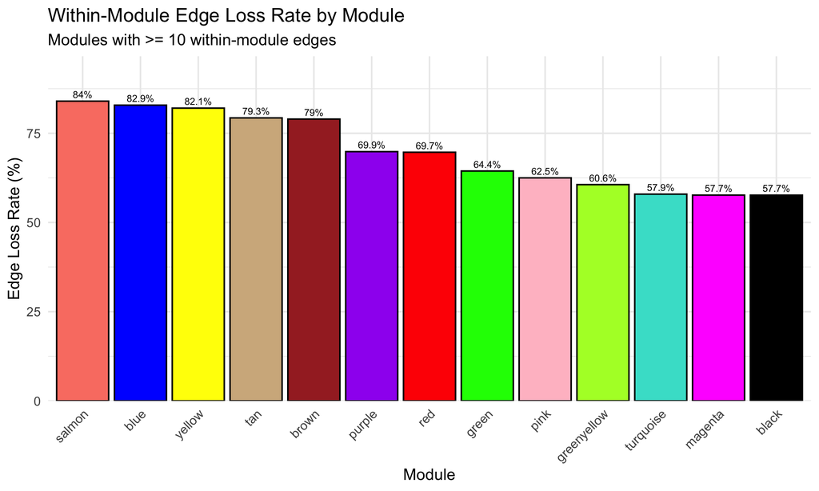

```r
module_loss <- ctrl_edges_with_modules %>%
  filter(same_module) %>%
  group_by(color1) %>%
  summarise(
    Total_Edges = n(),
    Lost = sum(is_lost),
    Preserved = sum(!is_lost),
    Loss_Rate = 100 * Lost / Total_Edges,
    .groups = "drop"
  ) %>%
  arrange(desc(Loss_Rate)) %>%
  dplyr::rename(Module = color1)

# Only plot modules with at least 10 edges
module_loss_plot <- module_loss %>%
  filter(Total_Edges >= 10)

if (nrow(module_loss_plot) > 0) {
  p_module_loss <- ggplot(
    module_loss_plot,
    aes(x = reorder(Module, -Loss_Rate), y = Loss_Rate, fill = Module)
  ) +
    geom_col(color = "black") +
    geom_text(aes(label = paste0(round(Loss_Rate, 1), "%")), vjust = -0.5, size = 3) +
    scale_fill_identity() +
    scale_y_continuous(expand = expansion(mult = c(0, 0.15))) +
    theme_minimal(base_size = 14) +
    theme(axis.text.x = element_text(angle = 45, hjust = 1)) +
    labs(
      title = "Within-Module Edge Loss Rate by Module",
      subtitle = "Modules with >= 10 within-module edges",
      x = "Module",
      y = "Edge Loss Rate (%)"
    )

  print(p_module_loss)

  ggsave(
    file.path(paths$figures, "wgcna_module_edge_loss.pdf"),
    p_module_loss, width = 12, height = 6
  )
}
```

```r
write_csv(module_loss, file.path(paths$intermediate, "wgcna_module_edge_loss.csv"))
```

# Vertex-Level MaizeNetome Analysis

This section analyzes network disruption from the perspective of individual genes (vertices) rather than edges. We ask: how many MaizeNetome connections does each gene have, and how many are preserved in Inv4m?

## MaizeNetome Edges Among WGCNA Genes

```r
# Filter MaizeNetome to edges where BOTH genes are in WGCNA gene set
mn_wgcna_edges <- MaizeNetome_v5 %>%
  filter(Element.ID.v5 %in% wgcna_genes & Direct.Connection.v5 %in% wgcna_genes) %>%
  rowwise() %>%
  mutate(
    g1 = min(Element.ID.v5, Direct.Connection.v5),
    g2 = max(Element.ID.v5, Direct.Connection.v5),
    edge_id = paste(g1, g2, sep = "_")
  ) %>%
  ungroup() %>%
  distinct(edge_id, g1, g2)

cat("=== MAIZENETOME EDGES AMONG WGCNA GENES ===\n")
```

```
## === MAIZENETOME EDGES AMONG WGCNA GENES ===
```

```r
cat("WGCNA genes:", length(wgcna_genes), "\n")
```

```
## WGCNA genes: 405
```

```r
cat("MaizeNetome edges between WGCNA genes:", nrow(mn_wgcna_edges), "\n")
```

```
## MaizeNetome edges between WGCNA genes: 1936
```

## MaizeNetome Edge Detection and Fate

```r
# Annotate MaizeNetome edges with detection status
mn_wgcna_edges <- mn_wgcna_edges %>%
  mutate(
    in_ctrl = edge_id %in% ctrl_edges$edge_id,
    in_inv4m = edge_id %in% inv4m_edges$edge_id,
    status = case_when(
      in_ctrl & in_inv4m ~ "preserved",
      in_ctrl & !in_inv4m ~ "lost",
      !in_ctrl & in_inv4m ~ "gained",
      TRUE ~ "not_detected"
    )
  )

cat("\n=== MAIZENETOME EDGE DETECTION ===\n")
```

```
##
## === MAIZENETOME EDGE DETECTION ===
```

```r
cat("MaizeNetome edges (between WGCNA genes):", nrow(mn_wgcna_edges), "\n")
```

```
## MaizeNetome edges (between WGCNA genes): 1936
```

```r
cat("Detected in CTRL:", sum(mn_wgcna_edges$in_ctrl),
    "(", round(100 * mean(mn_wgcna_edges$in_ctrl), 1), "%)\n")
```

```
## Detected in CTRL: 337 ( 17.4 %)
```

```r
cat("Detected in Inv4m:", sum(mn_wgcna_edges$in_inv4m),
    "(", round(100 * mean(mn_wgcna_edges$in_inv4m), 1), "%)\n")
```

```
## Detected in Inv4m: 280 ( 14.5 %)
```

```r
cat("\n=== MAIZENETOME EDGE FATE ===\n")
```

```
##
## === MAIZENETOME EDGE FATE ===
```

```r
mn_wgcna_edges %>%
  count(status) %>%
  mutate(pct = round(100 * n / sum(n), 1)) %>%
  arrange(desc(n)) %>%
  print()
```

```
## # A tibble: 4 × 3
##   status           n   pct
##   <chr>        <int> <dbl>
## 1 not_detected  1438  74.3
## 2 lost           218  11.3
## 3 gained         161   8.3
## 4 preserved      119   6.1
```

```r
# Store for summary
n_mn_wgcna_edges <- nrow(mn_wgcna_edges)
n_mn_detected_ctrl <- sum(mn_wgcna_edges$in_ctrl)
n_mn_preserved <- sum(mn_wgcna_edges$status == "preserved")
n_mn_lost <- sum(mn_wgcna_edges$status == "lost")
```

## Vertex-Level Statistics

```r
# Load gene labels for annotation
labels <- read_csv(
  file.path(paths$data, "locus_labels_master.csv"),
  show_col_types = FALSE
) %>%
  dplyr::select(gene, locus_label)

# For each gene, count MaizeNetome edges by status
vertex_stats <- bind_rows(
  mn_wgcna_edges %>% dplyr::select(gene = g1, status),
  mn_wgcna_edges %>% dplyr::select(gene = g2, status)
) %>%
  count(gene, status) %>%
  pivot_wider(names_from = status, values_from = n, values_fill = 0)

# Ensure all columns exist
for (col in c("preserved", "lost", "gained", "not_detected")) {
  if (!col %in% names(vertex_stats)) {
    vertex_stats[[col]] <- 0
  }
}

# Add totals and metadata
vertex_stats <- vertex_stats %>%
  mutate(
    mn_total = preserved + lost + gained + not_detected,
    mn_detected_ctrl = preserved + lost,
    mn_detected_inv4m = preserved + gained,
    pct_lost = ifelse(mn_detected_ctrl > 0, round(100 * lost / mn_detected_ctrl, 1), NA)
  ) %>%
  left_join(labels, by = "gene") %>%
  left_join(ctrl_modules %>% dplyr::select(gene, module, color), by = "gene") %>%
  arrange(desc(lost))

cat("=== VERTEX-LEVEL SUMMARY ===\n")
```

```
## === VERTEX-LEVEL SUMMARY ===
```

```r
cat("Genes with MaizeNetome edges:", nrow(vertex_stats), "\n")
```

```
## Genes with MaizeNetome edges: 231
```

```r
cat("Genes with edges detected in CTRL:", sum(vertex_stats$mn_detected_ctrl > 0), "\n")
```

```
## Genes with edges detected in CTRL: 154
```

## Genes Losing All MaizeNetome Connections

```r
# Genes that lose ALL their MaizeNetome connections in Inv4m
total_loss_genes <- vertex_stats %>%
  filter(mn_detected_ctrl > 0, preserved == 0)

cat("\n=== GENES LOSING ALL MAIZENETOME CONNECTIONS ===\n")
```

```
##
## === GENES LOSING ALL MAIZENETOME CONNECTIONS ===
```

```r
cat("Genes with CTRL edges but 0 preserved in Inv4m:", nrow(total_loss_genes),
    "(", round(100 * nrow(total_loss_genes) / sum(vertex_stats$mn_detected_ctrl > 0), 1), "%)\n\n")
```

```
## Genes with CTRL edges but 0 preserved in Inv4m: 80 ( 51.9 %)
```

```r
cat("Top 15 genes by number of lost edges:\n")
```

```
## Top 15 genes by number of lost edges:
```

```r
total_loss_genes %>%
  dplyr::select(gene, locus_label, color, mn_detected_ctrl, lost, preserved) %>%
  head(15) %>%
  print()
```

```
## # A tibble: 15 × 6
##    gene            locus_label color     mn_detected_ctrl  lost preserved
##    <chr>           <chr>       <chr>                <int> <int>     <int>
##  1 Zm00001eb191560 fanc        yellow                  12    12         0
##  2 Zm00001eb190870 zat5        blue                    10    10         0
##  3 Zm00001eb237580 duf295b     brown                   10    10         0
##  4 Zm00001eb195830 zhd18       turquoise                9     9         0
##  5 Zm00001eb188050 swr1        turquoise                7     7         0
##  6 Zm00001eb253420 rrp7        yellow                   7     7         0
##  7 Zm00001eb187050 duf295      blue                     6     6         0
##  8 Zm00001eb193660 nii2        brown                    6     6         0
##  9 Zm00001eb043750 pk1         magenta                  5     5         0
## 10 Zm00001eb282810 gata12      magenta                  5     5         0
## 11 Zm00001eb104420 qpt1        brown                    4     4         0
## 12 Zm00001eb188220 tsc10b      blue                     4     4         0
## 13 Zm00001eb192400 trx1        blue                     4     4         0
## 14 Zm00001eb200870 acsn1       yellow                   4     4         0
## 15 Zm00001eb007730 vdac2       turquoise                3     3         0
```

```r
# Store for summary
n_genes_total_loss <- nrow(total_loss_genes)
n_genes_with_mn_ctrl <- sum(vertex_stats$mn_detected_ctrl > 0)
```

## Top Genes by Absolute Edge Loss

```r
cat("\n=== TOP 20 GENES BY ABSOLUTE EDGE LOSS ===\n")
```

```
##
## === TOP 20 GENES BY ABSOLUTE EDGE LOSS ===
```

```r
vertex_stats %>%
  filter(mn_detected_ctrl > 0) %>%
  dplyr::select(gene, locus_label, color, mn_detected_ctrl, lost, preserved, pct_lost) %>%
  arrange(desc(lost)) %>%
  head(20) %>%
  print()
```

```
## # A tibble: 20 × 7
##    gene            locus_label color   mn_detected_ctrl  lost preserved pct_lost
##    <chr>           <chr>       <chr>              <int> <int>     <int>    <dbl>
##  1 Zm00001eb195960 duf309      blue                  22    21         1     95.5
##  2 Zm00001eb195270 bnl10.05    black                 22    14         8     63.6
##  3 Zm00001eb189960 <NA>        brown                 14    12         2     85.7
##  4 Zm00001eb191560 fanc        yellow                12    12         0    100
##  5 Zm00001eb019920 nfyb3       brown                 13    11         2     84.6
##  6 Zm00001eb188310 lpp2        brown                 12    10         2     83.3
##  7 Zm00001eb189950 nhl1        brown                 14    10         4     71.4
##  8 Zm00001eb190870 zat5        blue                  10    10         0    100
##  9 Zm00001eb195600 ptk2        brown                 13    10         3     76.9
## 10 Zm00001eb237580 duf295b     brown                 10    10         0    100
## 11 Zm00001eb189850 spp1        brown                 14     9         5     64.3
## 12 Zm00001eb189870 cct4        green                 19     9        10     47.4
## 13 Zm00001eb195830 zhd18       turquo…                9     9         0    100
## 14 Zm00001eb187200 aux1        brown                 13     7         6     53.8
## 15 Zm00001eb187970 wtf4        yellow                 8     7         1     87.5
## 16 Zm00001eb188040 rpl12       magenta               14     7         7     50
## 17 Zm00001eb188050 swr1        turquo…                7     7         0    100
## 18 Zm00001eb188360 pph         brown                 10     7         3     70
## 19 Zm00001eb192310 rpl39       yellow                12     7         5     58.3
## 20 Zm00001eb205670 rps8        pink                  11     7         4     63.6
```

## Module-Level MaizeNetome Summary

```r
cat("\n=== MAIZENETOME EDGE LOSS BY MODULE ===\n")
```

```
##
## === MAIZENETOME EDGE LOSS BY MODULE ===
```

```r
module_mn_summary <- vertex_stats %>%
  filter(mn_detected_ctrl > 0) %>%
  group_by(color) %>%
  summarise(
    genes = n(),
    total_mn_edges_ctrl = sum(mn_detected_ctrl),
    total_lost = sum(lost),
    total_preserved = sum(preserved),
    genes_total_loss = sum(preserved == 0),
    .groups = "drop"
  ) %>%
  mutate(pct_lost = round(100 * total_lost / total_mn_edges_ctrl, 1)) %>%
  arrange(desc(pct_lost))

print(module_mn_summary)
```

```
## # A tibble: 13 × 7
##    color   genes total_mn_edges_ctrl total_lost total_preserved genes_total_loss
##    <chr>   <int>               <int>      <int>           <int>            <int>
##  1 salmon      2                   2          2               0                2
##  2 tan         2                   2          2               0                2
##  3 blue       17                  68         62               6               12
##  4 purple      7                  10          9               1                6
##  5 yellow     16                  75         60              15               10
##  6 magenta     6                  31         21              10                3
##  7 black      13                  45         30              15                6
##  8 brown      24                 195        121              74                7
##  9 red         9                  13          8               5                6
## 10 pink       10                  31         18              13                6
## 11 green      12                  49         28              21                5
## 12 greeny…     7                  28         14              14                1
## 13 turquo…    29                 125         61              64               14
## # ℹ 1 more variable: pct_lost <dbl>
```

```r
write_csv(module_mn_summary, file.path(paths$intermediate, "wgcna_module_maizenetome_summary.csv"))
```

## Vertex Statistics Visualization

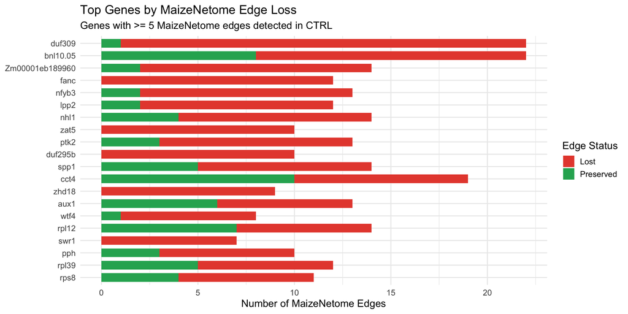

```r
# Plot genes with highest edge loss
top_loss_genes <- vertex_stats %>%
  filter(mn_detected_ctrl >= 5) %>%
  arrange(desc(lost)) %>%
  head(20) %>%
  mutate(
    label = ifelse(is.na(locus_label), gene, locus_label),
    label = factor(label, levels = rev(label))
  )

if (nrow(top_loss_genes) > 0) {
  p_vertex_loss <- ggplot(top_loss_genes, aes(x = label)) +
    geom_col(aes(y = mn_detected_ctrl, fill = "Lost"), width = 0.7) +
    geom_col(aes(y = preserved, fill = "Preserved"), width = 0.7) +
    coord_flip() +
    scale_fill_manual(
      values = c("Lost" = "#E74C3C", "Preserved" = "#27AE60"),
      name = "Edge Status"
    ) +
    theme_minimal(base_size = 14) +
    labs(
      title = "Top Genes by MaizeNetome Edge Loss",
      subtitle = "Genes with >= 5 MaizeNetome edges detected in CTRL",
      x = NULL,
      y = "Number of MaizeNetome Edges"
    )

  print(p_vertex_loss)

  ggsave(
    file.path(paths$figures, "wgcna_vertex_maizenetome_loss.pdf"),
    p_vertex_loss, width = 12, height = 8
  )
  ggsave(
    file.path(paths$figures, "wgcna_vertex_maizenetome_loss.png"),
    p_vertex_loss, width = 12, height = 8, dpi = 300
  )
}
```

```r
# Save vertex stats
write_csv(vertex_stats, file.path(paths$intermediate, "wgcna_vertex_maizenetome_stats.csv"))
```

# Export Edge Lists

```r
# Export CTRL edges with annotations
ctrl_edges_export <- ctrl_edges_with_modules %>%
  dplyr::select(
    gene1, gene2, edge_id, r, p_adj,
    in_maizenetome, module1, module2, same_module, is_lost
  )

write_csv(ctrl_edges_export, file.path(paths$intermediate, "wgcna_ctrl_edges.csv"))

# Export Inv4m edges
inv4m_edges_export <- inv4m_edges %>%
  dplyr::select(gene1, gene2, edge_id, r, p_adj, in_maizenetome)

write_csv(inv4m_edges_export, file.path(paths$intermediate, "wgcna_inv4m_edges.csv"))

# Export edge comparison summary with sign concordance
edge_comparison <- data.frame(
  edge_id = unique(c(ctrl_edge_set, inv4m_edge_set))
) %>%
  mutate(
    in_ctrl = edge_id %in% ctrl_edge_set,
    in_inv4m = edge_id %in% inv4m_edge_set,
    in_maizenetome = edge_id %in% maizenetome_edges$edge_id,
    status = case_when(
      in_ctrl & in_inv4m ~ "Shared",
      in_ctrl & !in_inv4m ~ "Lost",
      !in_ctrl & in_inv4m ~ "Gained"
    )
  ) %>%
  left_join(
    shared_edge_correlations %>%
      dplyr::select(edge_id, r_ctrl, r_inv4m, same_sign, sign_pattern),
    by = "edge_id"
  )

write_csv(edge_comparison, file.path(paths$intermediate, "wgcna_edge_comparison.csv"))

cat("=== EXPORTED FILES ===\n")
```

```
## === EXPORTED FILES ===
```

```r
cat("wgcna_ctrl_edges.csv:", nrow(ctrl_edges_export), "edges\n")
```

```
## wgcna_ctrl_edges.csv: 12593 edges
```

```r
cat("wgcna_inv4m_edges.csv:", nrow(inv4m_edges_export), "edges\n")
```

```
## wgcna_inv4m_edges.csv: 9460 edges
```

```r
cat("wgcna_edge_comparison.csv:", nrow(edge_comparison), "unique edges\n")
```

```
## wgcna_edge_comparison.csv: 18823 unique edges
```

```r
cat("wgcna_maizenetome_validation_stats.csv: summary statistics\n")
```

```
## wgcna_maizenetome_validation_stats.csv: summary statistics
```

```r
cat("wgcna_module_edge_loss.csv: module-level edge loss\n")
```

```
## wgcna_module_edge_loss.csv: module-level edge loss
```

```r
cat("wgcna_vertex_maizenetome_stats.csv: vertex-level MaizeNetome stats\n")
```

```
## wgcna_vertex_maizenetome_stats.csv: vertex-level MaizeNetome stats
```

```r
cat("wgcna_module_maizenetome_summary.csv: module-level MaizeNetome summary\n")
```

```
## wgcna_module_maizenetome_summary.csv: module-level MaizeNetome summary
```

# Summary

```r
cat("\n")
```

```r
cat("=" %>% rep(60) %>% paste(collapse = ""), "\n")
cat("WGCNA NETWORK VALIDATION SUMMARY\n")
```

```
## WGCNA NETWORK VALIDATION SUMMARY
```

```r
cat("=" %>% rep(60) %>% paste(collapse = ""), "\n\n")
cat("NETWORK CONSTRUCTION\n")
```

```
## NETWORK CONSTRUCTION
```

```r
cat("  Genes:", length(wgcna_genes), "\n")
```

```
##   Genes: 405
```

```r
cat("  Method: Pearson correlation, FDR < 0.05\n")
```

```
##   Method: Pearson correlation, FDR < 0.05
```

```r
cat("  (Same parameters as trans-network analysis)\n\n")
```

```
##   (Same parameters as trans-network analysis)
```

```r
cat("CTRL NETWORK\n")
```

```
## CTRL NETWORK
```

```r
cat("  Total edges:", scales::comma(nrow(ctrl_edges)), "\n")
```

```
##   Total edges: 12,593
```

```r
cat("  Reference (MaizeNetome):", scales::comma(sum(ctrl_edges$in_maizenetome)),
    "(", round(100 * mean(ctrl_edges$in_maizenetome), 1), "%)\n")
```

```
##   Reference (MaizeNetome): 337 ( 2.7 %)
```

```r
cat("  Novel:", scales::comma(sum(!ctrl_edges$in_maizenetome)), "\n\n")
```

```
##   Novel: 12,256
```

```r
cat("INV4M NETWORK\n")
```

```
## INV4M NETWORK
```

```r
cat("  Total edges:", scales::comma(nrow(inv4m_edges)), "\n")
```

```
##   Total edges: 9,460
```

```r
cat("  Reference (MaizeNetome):", scales::comma(sum(inv4m_edges$in_maizenetome)),
    "(", round(100 * mean(inv4m_edges$in_maizenetome), 1), "%)\n")
```

```
##   Reference (MaizeNetome): 280 ( 3 %)
```

```r
cat("  Novel:", scales::comma(sum(!inv4m_edges$in_maizenetome)), "\n\n")
```

```
##   Novel: 9,180
```

```r
cat("NETWORK DISRUPTION\n")
```

```
## NETWORK DISRUPTION
```

```r
cat("  Shared edges:", scales::comma(length(shared_edges)), "\n")
```

```
##   Shared edges: 3,230
```

```r
cat("  Lost edges:", scales::comma(length(ctrl_only_edges)),
    "(", round(100 * length(ctrl_only_edges) / nrow(ctrl_edges), 1), "% of CTRL)\n")
```

```
##   Lost edges: 9,363 ( 74.4 % of CTRL)
```

```r
cat("  Gained edges:", scales::comma(length(inv4m_only_edges)), "\n\n")
```

```
##   Gained edges: 6,230
```

```r
cat("SIGN CONCORDANCE (signed network validation)\n")
```

```
## SIGN CONCORDANCE (signed network validation)
```

```r
cat("  Shared edges with same sign:", scales::comma(n_truly_preserved),
    "(", round(100 * n_truly_preserved / length(shared_edges), 1), "%)\n")
```

```
##   Shared edges with same sign: 3,134 ( 97 %)
```

```r
cat("  Shared edges with sign flip:", scales::comma(n_sign_flips),
    "(", round(100 * n_sign_flips / length(shared_edges), 1), "%)\n")
```

```
##   Shared edges with sign flip: 96 ( 3 %)
```

```r
cat("  MaizeNetome edges - same sign:", n_mn_truly_preserved, "/", nrow(shared_mn_correlations),
    "(", round(100 * n_mn_truly_preserved / nrow(shared_mn_correlations), 1), "%)\n\n")
```

```
##   MaizeNetome edges - same sign: 118 / 119 ( 99.2 %)
```

```r
if (fisher_result$p.value < 0.05) {
  cat("MAIZENETOME VALIDATION\n")
  cat("  Reference edges are", ifelse(fisher_result$estimate > 1, "MORE", "LESS"),
      "likely to be preserved\n")
  cat("  Odds ratio:", round(fisher_result$estimate, 2),
      "(p =", signif(fisher_result$p.value, 3), ")\n\n")
}
```

```
## MAIZENETOME VALIDATION
##   Reference edges are MORE likely to be preserved
##   Odds ratio: 1.6 (p = 6.46e-05 )
```

```r
cat("VERTEX-LEVEL MAIZENETOME ANALYSIS\n")
```

```
## VERTEX-LEVEL MAIZENETOME ANALYSIS
```

```r
cat("  MaizeNetome edges among WGCNA genes:", scales::comma(n_mn_wgcna_edges), "\n")
```

```
##   MaizeNetome edges among WGCNA genes: 1,936
```

```r
cat("  Detected in CTRL:", scales::comma(n_mn_detected_ctrl),
    "(", round(100 * n_mn_detected_ctrl / n_mn_wgcna_edges, 1), "%)\n")
```

```
##   Detected in CTRL: 337 ( 17.4 %)
```

```r
cat("  Preserved (in both):", scales::comma(n_mn_preserved),
    "(", round(100 * n_mn_preserved / n_mn_wgcna_edges, 1), "%)\n")
```

```
##   Preserved (in both): 119 ( 6.1 %)
```

```r
cat("  Lost (CTRL only):", scales::comma(n_mn_lost),
    "(", round(100 * n_mn_lost / n_mn_wgcna_edges, 1), "%)\n")
```

```
##   Lost (CTRL only): 218 ( 11.3 %)
```

```r
cat("  Genes losing ALL MaizeNetome connections:", n_genes_total_loss,
    "/", n_genes_with_mn_ctrl,
    "(", round(100 * n_genes_total_loss / n_genes_with_mn_ctrl, 1), "%)\n")
```

```
##   Genes losing ALL MaizeNetome connections: 80 / 154 ( 51.9 %)
```

```r
cat("\n")
```

```r
cat("=" %>% rep(60) %>% paste(collapse = ""), "\n")
```